# Sales Analysis

Afsar Ali

```r
# Course: BUAN 5210
# Title: Post Promo and Ad analysis
# Purpose: Make recommendations regarding promotions and advertisements
# Data: MTP_Data.csv
# Date: Oct 26, 2017
```

```r
#   Clear workspace at begining
rm(list = ls(all = TRUE))

# Load packages
library(tidyverse)
library(GGally)
library(gridExtra)
library(kableExtra)

# Load Data
mtp <- read.csv("MTP_Data.csv")

#Initial Review of the data
glimpse(mtp)
```

```
## Observations: 1,995
## Variables: 8
## $ units  <int> 10, 6, 3, 4, 9, 22, 20, 23, 12, 17, 1, 4, 8, 21, 8, 13,...
## $ brand  <fct> GENERAL MILLS CINNAMON TST CR, GENERAL MILLS CINNAMON T...
## $ flavor <fct> CINNAMON TOAST, CINNAMON TOAST, CINNAMON TOAST, CINNAMO...
## $ grain  <fct> WHOLE WHEAT AND RICE, WHOLE WHEAT AND RICE, WHOLE WHEAT...
## $ promo  <int> 0, 0, 0, 0, 0, 1, 0, 1, 1, 0, 1, 0, 0, 0, 0, 0, 0, 0, 0...
## $ ad     <fct> NONE, A, NONE, NONE, NONE, B, B, NONE, NONE, NONE, NONE...
## $ volume <dbl> 0.06, 0.06, 0.12, 0.98, 0.98, 0.98, 0.80, 0.80, 0.80, 0...
## $ price  <dbl> 0.50, 0.50, 1.05, 3.50, 2.99, 2.48, 3.19, 1.77, 2.50, 3...
```

```r
# Add Total Sale and Total volume to the data frame
mtp<- mutate(mtp, TotalSale = units*price)
mtp<- mutate(mtp, TotalVolume = units*volume)

# Seprate by Compancy
mtp <- mtp %>%
    separate(brand, into = c("company", "brand"), sep = "\\ ", extra = "merge")

## Making the Data Pretty
library(plyr)
mtp$promo<- factor(mtp$promo)
mtp$promo<- revalue(mtp$promo, c ("0" = "No Promo", "1" = "Promo"))
mtp$ad<- revalue(mtp$ad, c ("NONE" = "No Ad", "A" = "Big Ad", "B" = "Mid/Small Ad"))
mtp$company<- revalue(mtp$company, c ("GENERAL" = "GENERAL MILLS"))
mtp$brand<- revalue(mtp$brand, c ("MILLS CINNAMON TST CR" = "CINNAMON TST CR"))
library(tidyverse)

#review the updated data
glimpse(mtp)
```

```
## Observations: 1,995
## Variables: 11
## $ units       <int> 10, 6, 3, 4, 9, 22, 20, 23, 12, 17, 1, 4, 8, 21, 8...
## $ company     <chr> "GENERAL MILLS", "GENERAL MILLS", "GENERAL MILLS",...
## $ brand       <chr> "CINNAMON TST CR", "CINNAMON TST CR", "CINNAMON TS...
## $ flavor      <fct> CINNAMON TOAST, CINNAMON TOAST, CINNAMON TOAST, CI...
## $ grain       <fct> WHOLE WHEAT AND RICE, WHOLE WHEAT AND RICE, WHOLE ...
## $ promo       <fct> No Promo, No Promo, No Promo, No Promo, No Promo, ...
## $ ad          <fct> No Ad, Big Ad, No Ad, No Ad, No Ad, Mid/Small Ad, ...
## $ volume      <dbl> 0.06, 0.06, 0.12, 0.98, 0.98, 0.98, 0.80, 0.80, 0....
## $ price       <dbl> 0.50, 0.50, 1.05, 3.50, 2.99, 2.48, 3.19, 1.77, 2....
## $ TotalSale   <dbl> 5.00, 3.00, 3.15, 14.00, 26.91, 54.56, 63.80, 40.7...
## $ TotalVolume <dbl> 0.60, 0.36, 0.36, 3.92, 8.82, 21.56, 16.00, 18.40,...
```

# Introduction

This memo provides a brief analysis of the sales data provided by the Post Cereal Company, with particular focus given to how promotions and advertising translate into sales, in terms of both units sold and sales dollars. No cost information was provided therefore a cost benefit analysis is not included. An initial look at the data reveals that, of the 11 brands in the data set, Kellogg carries 8, while Post carries only 2, and General Mills with 1.

```r
kable(mtp %>%
  group_by(brand, company ) %>%
  select(company) %>%
  table())
```

|  | GENERAL MILLS | KELLOGGS | POST |
| --- | --- | --- | --- |
| APPLE JACKS | 0 | 163 | 0 |
| CINNAMON TST CR | 185 | 0 | 0 |
| CORN FLAKES | 0 | 153 | 0 |
| CORN POPS | 0 | 165 | 0 |
| FROOT LOOPS | 0 | 162 | 0 |
| FROSTED FLAKES | 0 | 251 | 0 |
| FROSTED MINI WHEATS | 0 | 198 | 0 |
| HONEY BUNCHES OF OATS | 0 | 0 | 232 |
| RICE KRISPIES | 0 | 144 | 0 |
| SHREDDED WHEAT | 0 | 0 | 189 |
| SMART START | 0 | 153 | 0 |

# Finding 1: Kellogg has the most sale

This broad analysis of the data shows that Post Cereal is a distant second to Kellogg Cereal in terms of Sales, Units Sold, Number of Promotions, and Number of Ads (all types), and General Mills ranks last by all variables. These findings are reasonable given that Kellogg makes up the largest proportion of observations in the data. To normalize this discrepancy the rest of the analysis looks at trends on a Brand level, and we will not be examining the General Mills data as we only have data on a single brand. This graph shows a how Post sales are compared to General Mills and Kellogg.

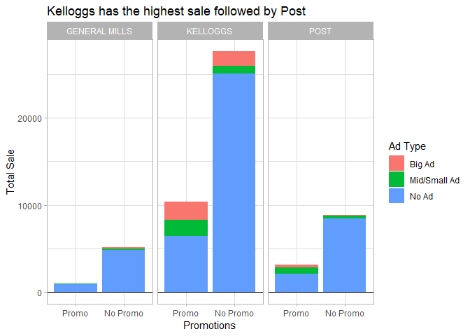

```r
ggplot(mtp, aes(x=reorder(promo, desc(TotalSale)), y= TotalSale, fill = ad)) +
  stat_summary(fun.y = "sum", geom ="bar", position = "stack") +
  geom_hline(yintercept = 0, color = "black") +
  labs(fill = "Ad Type") +
  ggtitle("Kelloggs has the highest sale followed by Post") +
  ylab("Total Sale") +
  xlab("Promotions") +
  theme_light() +
  facet_grid(. ~ company)
```